# P8104 Homework 3

Jenna Mohammed

2023-10-11

```r
library(ggridges)
library(tidyverse)
```

```r
library(patchwork)
library(dplyr)
library(ggplot2)

library(p8105.datasets)
data("instacart")

library(p8105.datasets)
data("brfss_smart2010")
```

# Problem 1

### Loading in Data

```r
instacart |>
  count(aisle) |>
  arrange(desc(n))
```

```
## # A tibble: 134 x 2
##    aisle                              n
##    <chr>                          <int>
##  1 fresh vegetables              150609
##  2 fresh fruits                  150473
##  3 packaged vegetables fruits     78493
##  4 yogurt                         55240
##  5 packaged cheese                41699
##  6 water seltzer sparkling water  36617
##  7 milk                           32644
##  8 chips pretzels                 31269
##  9 soy lactosefree                26240
## 10 bread                          23635
## # i 124 more rows
```

There are 134 aisles, with fresh vegetables and fresh fruit having the most ordered items.

### Plot that Shows the Number of Items Ordered in Each Aisle

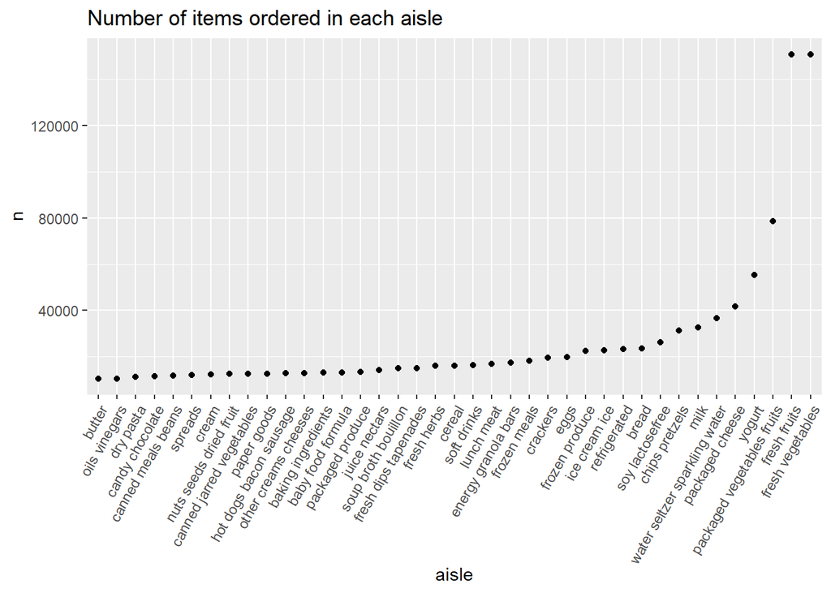

```r
instacart |>
  count(aisle) |>
  filter(n > 10000) |>
  mutate(aisle = fct_reorder(aisle, n)) |>
  ggplot(aes(x = aisle, y = n)) +
  geom_point() +
  labs(title = "Number of items ordered in each aisle") +
  theme(axis.text.x = element_text(angle = 60, hjust = 1))
```

### Table of the Three Most Popular Items in Aisles `baking ingredients`, `dog food care`, and `packaged vegetables fruits`

```r
instacart |>
  filter(aisle %in% c("baking ingredients", "dog food care", "packaged vegetables fruits")) |>
  group_by(aisle) |>
  count(product_name) |>
  mutate(rank = min_rank(desc(n))) |>
  filter(rank < 4) |>
  arrange(desc(n)) |>
  knitr::kable()
```

| aisle | product_name | n | rank |
| --- | --- | --- | --- |
| packaged vegetables fruits | Organic Baby Spinach | 9784 | 1 |
| packaged vegetables fruits | Organic Raspberries | 5546 | 2 |
| packaged vegetables fruits | Organic Blueberries | 4966 | 3 |
| baking ingredients | Light Brown Sugar | 499 | 1 |
| baking ingredients | Pure Baking Soda | 387 | 2 |
| baking ingredients | Cane Sugar | 336 | 3 |
| dog food care | Snack Sticks Chicken & Rice Recipe Dog Treats | 30 | 1 |
| dog food care | Organix Chicken & Brown Rice Recipe | 28 | 2 |
| dog food care | Small Dog Biscuits | 26 | 3 |

### Table showing the mean hour of the day at which `Pink Lady Apples` and `Coffee Ice Cream` are ordered on each day of the week

```r
instacart |>
  filter(product_name %in% c("Pink Lady Apples", "Coffee Ice Cream")) |>
  group_by(product_name, order_dow) |>
  summarize(mean_hour = mean(order_hour_of_day)) |>
  pivot_wider(
    names_from = order_dow,
    values_from = mean_hour) |>
  knitr::kable(digits = 2)
```

| product_name | 0 | 1 | 2 | 3 | 4 | 5 | 6 |
| --- | --- | --- | --- | --- | --- | --- | --- |
| Coffee Ice Cream | 13.77 | 14.32 | 15.38 | 15.32 | 15.22 | 12.26 | 13.83 |
| Pink Lady Apples | 13.44 | 11.36 | 11.70 | 14.25 | 11.55 | 12.78 | 11.94 |

# Problem 2

### Loading in and cleaning the data

```r
view(brfss_smart2010)

brfss_df <- brfss_smart2010 |>
  janitor::clean_names() |>
  filter(
    topic == "Overall Health",
    response %in% c("Excellent", "Very good", "Good", "Fair", "Poor")
    ) |>
  mutate(
    response = factor(response, levels = c("Poor", "Fair", "Good", "Very good", "Excellent"))
  )

view(brfss_df)
```

### Determining Which States Were Observed at 7 or More Locations

```r
states_observed_df <- brfss_df |>
  filter(year %in% c(2002, 2010)) |>
  select(year, locationabbr, locationdesc) |>
  distinct() |>
    group_by(year, locationabbr) |>
  summarize(n=n()) |>
  filter(n >= 7) |>
  arrange(year, desc(n))
view(states_observed_df)
```

In 2002, Pennsylvania, Massachusetts,Jew Jersey, Conneticut, Florida, and North Carolina were observed 7 or more times. In 2010, Florida, New Jersey, Texas, California, Maryland, North Carolina, New England, Washington, Massachusets, New York, Ohio, Colorado, Pennsylvania, and South Carolina were observed 7 or more times.

### Construct a Dataset and Plot

```r
# creating a datatset filtering "Excellent" values

Excellent_dataset <- brfss_df |>
  janitor::clean_names() |>
  filter(response == "Excellent")

#view(Excellent_dataset)

# averaging the values

average_df <- Excellent_dataset %>%
  group_by(year, locationabbr) %>%
  summarize(average_df = mean(data_value, na.rm = TRUE))
```

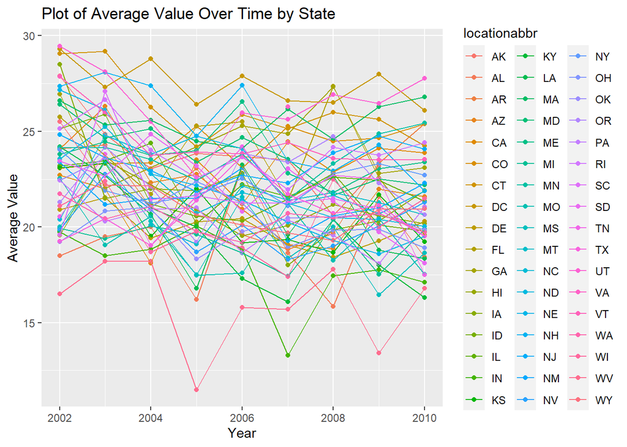

```r
#view(average_df)

# make a spaghetti plot of the average value over time depending on state

ggplot(average_df, aes(x = year, y = average_df, group = locationabbr, color = locationabbr)) +
  geom_point() +
  geom_line() +
  labs( title = "Plot of Average Value Over Time by State",
    x = "Year",
    y = "Average Value")
```

The spaghetti plot above depicts the average data values from 2002 through 2010 from `average_df` among all states in the United States.

### Making a Two Panel Plot in NY Data

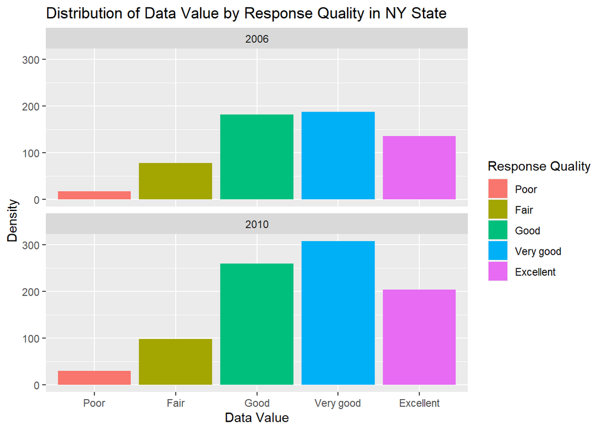

```r
ny_df <- brfss_df %>%
  filter(locationabbr == "NY" & year %in% c(2006, 2010) & response %in% c("Poor", "Fair", "Good", "Very good", "Excellent"))

ggplot(ny_df, aes(y = data_value, x = response ), alpha = 0.7) +
  geom_col(aes(fill = response)) +
    facet_wrap(~year, ncol = 1) +
    labs(title = "Distribution of Data Value by Response Quality in NY State",
       x = "Data Value",
       y = "Density",
       fill = "Response Quality")
```

The above graph depicts the distribution of data value response quality in NY state in 2006 and 2010 from `ny_df`. The two plots follow a similar distribution, however the 2010 graph shows higher density compared to 2006.

# Problem 3

### Load in and Tidy Data for Participants

```r
covar_df = read_csv("./nhanes_covar.csv", skip = 4) %>%
  janitor::clean_names() |>
  mutate(sex,sex=ifelse(sex==1,"Male","Female"))|>
  mutate(sex,sex=as_factor(sex))|>
  mutate(education = recode(education, "1" = "Less than high school", "2" = "High school equivalent", "3" = "More than high school")) |>
  filter(age>=21)|>
  drop_na()|>

view(covar_df)
```

### Load in and Tidy Data for Accelerator

```r
accel_df = read_csv("./nhanes_accel.csv") |>
  janitor::clean_names() |>
  drop_na()
view(accel_df)
```

### Merge Participant and Accelerator Data

```r
combined_data <- left_join(covar_df,accel_df,by= "seqn")

view(combined_data)
```

### Producing a Reader-Friendly Table

```r
combined_data |>
group_by(sex,education)|>
  summarize(n_people=n())|>

  pivot_wider(
    names_from = education,
    values_from = n_people
  )
```

[output not shown]

```
## # A tibble: 2 x 4
## # Groups:   sex [2]
##   sex    `High school equivalent` `Less than high school` More than high schoo~1
##   <fct>                     <int>                   <int>                  <int>
## 1 Male                         35                      27                     56
## 2 Female                       23                      28                     59
## # i abbreviated name: 1: `More than high school`
```

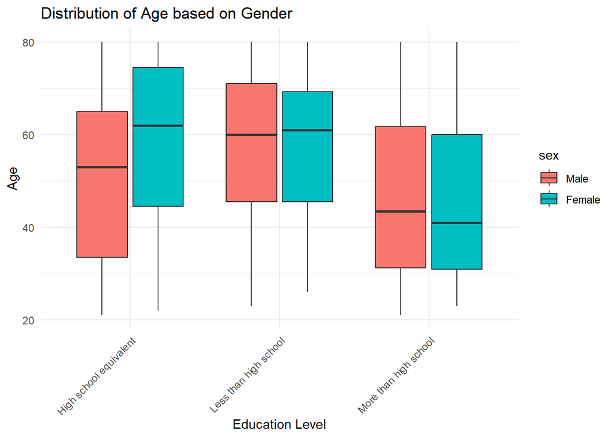

```r
# creating a plot for the above data

ggplot(combined_data, aes(x = education, y = age, fill = sex)) +
  geom_boxplot() +
  labs(title = "Distribution of Age based on Gender",
       x = "Education Level",
       y = "Age") +
  theme_minimal() +
  theme(axis.text.x = element_text(angle = 45, hjust = 1))
```

### Creating the Plot for Total Activities

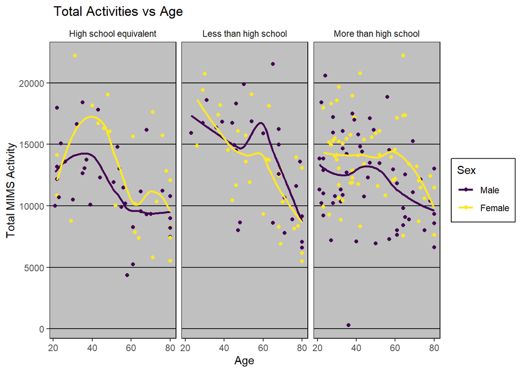

```r
combined_data |>
   mutate(total_act = rowSums(across(min1:min1440)))|>
  ggplot(aes(x=age,y=total_act, color = sex)) +
  geom_point(size = 1.5)  +
  geom_smooth(se=FALSE) +
  labs(
    y="Total MIMS Activity",
    x = "Age",
    title = " Total Activities vs Age ") +
  viridis::scale_color_viridis(name = "Sex", discrete = TRUE) +
    ggthemes::theme_excel() +
  facet_grid(.~education)
```

### 3 Panel Plot that Shows Activity Throughout The course of a Day

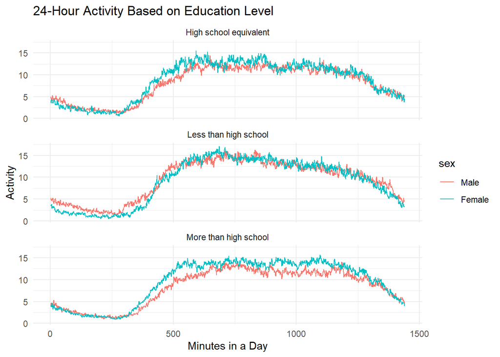

```r
activity_24 = combined_data |>
  pivot_longer(
    min1:min1440,names_to = "time",
    values_to = "activity",
    names_prefix = "min")|>
  mutate(time = as.numeric(time))|>
  group_by( time, education, sex)|>
  mutate(activity = mean(activity))

# create the plot using ggplot

activity_plot <- activity_24 |>
  ggplot(aes(x = time, y = activity, color = sex)) +
  geom_line() +
  facet_wrap(~education, ncol = 1) +
  labs(title = "24-Hour Activity Based on Education Level",
       x = "Minutes in a Day",
       y = "Activity") +
  theme_minimal()

activity_plot
```

The above plot shows a similar pattern for males and females on activity among all three panels. However, for the graphs`High school equivalent` and `More than high school`, females show to have slightly higher activity levels.